# OncoSimulR: Frequency-dependent fitness

## 5.3 Heterogeneous tumours:

If the benefit from an extra unit of vascularisation in a fully aerobic group is lower than the cost c to produce that unit, then for a sufficiently low proportion of GLY and thus sufficiently large number of aerobic cells sharing the club good, DEF will have higher fitness than VOP. This will lead to a decrease in the proportion of VOP among aerobic cells and thus a decrease in the average fitness of aerobic cells. A lower fitness in aerobic cells will lead to an increase in the proportion of GLY until the aerobic groups (among which the club good is split) get sufficiently small and fitness starts to favour VOP over DEF, swinging the dynamics back.

```r
# Definition of the function for creating the corresponding dataframe.
avc <- function (a, v, c) {
  data.frame(Genotype = c("WT", "GLY", "VOP", "DEF"),
             Fitness = c("1",
                         paste0("1 + ",a," * (f_1 + 1)"),
                         paste0("1 + ",a," * f_1 + ",v," * (f_2 + 1) - ",c),
                         paste0("1 + ",a," * f_1 + ",v," * f_2")
                         ))
                          }

# Specification of the different effects on fitness.
afavc <- allFitnessEffects(genotFitness = avc(7.5, 2, 1),
                           frequencyDependentFitness = TRUE,
                           frequencyType = "rel")

# Launching of the simulation (20 times).
simulation <- oncoSimulPop(20,
                           mc.cores = n_cores,
                           afavc,
                           model = "McFL",
                           onlyCancer = FALSE,
                           finalTime = 25,
                           mu = 1e-2,
                           initSize = 4000,
                           keepPhylog = TRUE,
                           seed = NULL,
                           errorHitMaxTries = FALSE,
                           errorHitWallTime = FALSE)
```

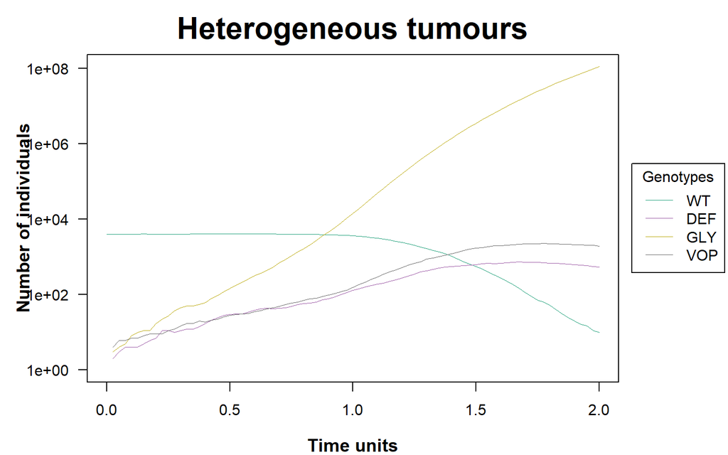

```r
# Representation of the plot of one simulation as an example (the others are
# highly similar).
plot(simulation[[1]], show = "genotypes", type = "line",
     ylab = "Number of individuals", main = "Heterogeneous tumours",
     font.main=2, font.lab=2, cex.main=2, cex.lab=1.2, las = 1)
```

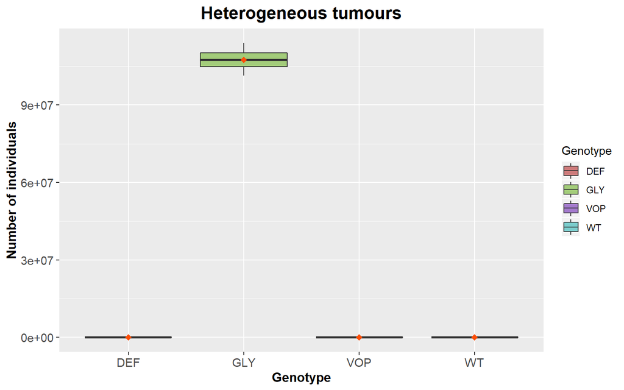

```r
# Representation of a boxplot considering all the simulations.
compositionPop2(simulation, ylab = "Number of individuals",
                main = "Heterogeneous tumours")
```

# 6 Prostate cancer tumour–stroma interactions

This example is based on the paper *Investigating prostate cancer tumour–stroma* *interactions: clinical and biological insights from an evolutionary game* 2, available at http://dx.doi.org/10.1038/bjc.2011.517. The authors apply an Evolutionary Game Theory to modelling the behavior and progression of a prostate tumour formed by three different cell populations: stromal cells, a dependant tumour phenotype capable of co-opting stromal cells to support its growth and an independent tumour phenotype that does not require microenvironmental support, be it stromal associated or not. To enable this, the model has four variables, which is the minimun necessity to describe the relationships in terms of costs and benefits between the different types of cells and, of course, to describe the progression of the cancer.

The different cell types, hence, are as follows:

1. S: stromal cells.
2. D: microenvironmental-dependent tumour cells.
3. I: microenvironmental-independent tumour cells.

And the parameters that describe the relationships are as follows:

- $\alpha$: benefit derived from the cooperation between a S cell and a D cell.
- $\beta$: cost of extracting resources from the microenvironment.
- $\gamma$: cost of being microenvironmentally independent.
- $\rho$: benefit derived by D from paracrine growth factors produced by I cells.

Table 2 shows the playoffs for each cell type when interacting with others. It is noted that in this model no other phenotypes are relevant in the context of the game and spatial considerations will not affect the outcome.

Table 2: Playoff table that represents the interactions between the three cell types considered by de model

| . | S | D | I |
| --- | --- | --- | --- |
| **S** | $0$ | $\alpha$ | $0$ |
| **D** | $1+\alpha-\beta$ | $1-2\beta$ | $1-\beta+\rho$ |
| **I** | $1-\gamma$ | $1-\gamma$ | $1-\gamma$ |

From these variables, the fitness of each cell population $(W\left(S\right), W\left(I\right), W\left(D\right))$ is as follows:

$$\begin{equation}
W\left(S\right) = 1 + f_3\alpha
\tag{1}
\end{equation}$$
$$\begin{equation}
W\left(I\right) = 2 - \gamma
\tag{2}
\end{equation}$$
$$\begin{equation}
W\left(D\right) = 1 + \left(1 - f_2 - f_3\right)\left(1 - \beta +
\alpha\right) +\\
f_2\left(1 - \beta + \rho\right) + f_3(1 - 2\beta) + \\
1 - \beta + \alpha + f_2\left(\rho - \alpha\right) - f_3\left(\beta +
\alpha\right)
\tag{3}
\end{equation}$$

where $f_2$ is the frequency of I cells and $f_3$ is the frequency of D cells at a given time. All fitness equations start from balance by the sum of 1.

## 6.1 Simulations

First, we define the fitness of the different genotypes (see Equations (1), (2) and (3)) through the function *fitness_rel* that builds a data frame.

It is important to note that this program models a situation where, from a WT cell population, the rest of the cell population types are formed. However, this model has also stromal cells that are not formed from a WT, since they are not tumour cells although interacting with it. Hence, for this model, we can not represent scenarios with total biological accuracy, something that we must consider when interpreting the results.

```r
fitness_rel <- function(a, b, r, g, gt = c("WT", "S", "I", "D")) {
    data.frame(
      Genotype = gt,
      Fitness = c("1",
                  paste0("1 + ", a, " * f_3"),
                  paste0("1 + 1 - ", g),
                  paste0("1 + (1 - f_2 - f_3) * (1 - ", b, " + ",
                         a, ") + f_2 * (1 - ", b, " + ", r,
                         ") + f_3 * (1 - 2 * ", b, ") + 1 - ", b,
                         " + ", a, " + f_2 * (", r, " - ",
                         a, ") - f_3 * (", b, " + ", a, ")"))
                  )
}
```

Then, we are going to model different scenarios that represent different biological situations. In this case, we are going to explain four possible situations.

**Note:** for these simulations the values of paratemers are normalised in the range (0 : 1) so 1 represents the maximum value for any parameter being positive of negative to fitness depending on the parameter.

### 6.1.1 First scenario

In this simulation, we are modelling a situation where the environment is relatively resource-poor. Besides, we set a intermediate cooperation between D-D and D-I and a very low benefit from coexistence of D with I.

- $\alpha$ (a) = 0.5: intermediate cooperation between D and D cells.
- $\beta$ (b) = 0.7: relatively resource-poor microenvironment.
- $\rho$ (p) = 0.1: low benefit of D cells.
- $\gamma$ (g) = 0.8: high cost of independence of I cells.

We can observe that high values of $\alpha$ and low values of $\rho$ are translated in a larger profit of D cells from his interaction with S cells than from his interaction with I cells. Besides, because of the high cost of independence of I cells ($\gamma$), it is not surprise that this population ends up becoming extinct. Finally, the tumour is composed by two cellular types: D and S cells.

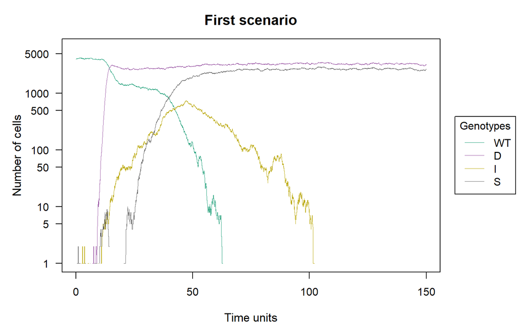

```r
scen1 <- allFitnessEffects(genotFitness = fitness_rel(a = 0.5, b = 0.7,
                                                     r = 0.1, g = 0.8),
                          frequencyDependentFitness = TRUE,
                          frequencyType = "rel")

simulScen1 <- oncoSimulIndiv(scen1,
                              model = "McFL",
                              onlyCancer = FALSE,
                              finalTime = 150,
                              mu = 1e-4,
                              initSize = 4000,
                              keepPhylog = TRUE,
                              seed = NULL,
                              errorHitMaxTries = FALSE,
                              errorHitWallTime = FALSE)

plot(simulScen1, show = "genotypes", type = "line",
     main = "First scenario",
     cex.main = 1.3, cex.lab = 1.1,
     las = 1)
```

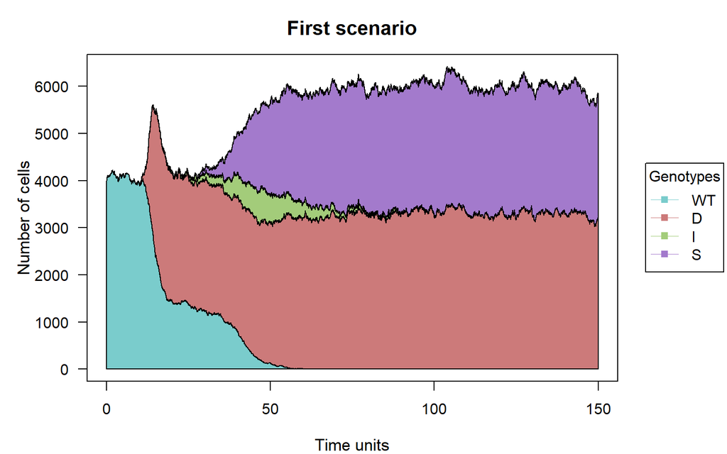

```r
plot(simulScen1, show = "genotypes",
     main = "First scenario",
     cex.main = 1.3, cex.lab = 1.1,
     las = 1)
```

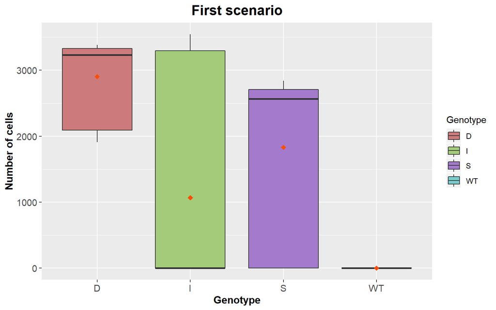

```r
simulScen1Pop <- oncoSimulPop(20,
                              scen1,
                              model = "McFL",
                              onlyCancer = FALSE,
                              mc.cores = n_cores,
                              finalTime = 150,
                              mu = 1e-4,
                              initSize = 4000,
                              keepPhylog = TRUE,
                              seed = NULL,
                              errorHitMaxTries = FALSE,
                              errorHitWallTime = FALSE)

compositionPop2(simulScen1Pop,
                main = "First scenario",
                ylab = "Number of cells")
```

### 6.1.2 Second scenario

In this case, we set $\alpha$ lower than in the first scenario and we enable the indepenence of I cells through a lower $\gamma$.

- $\alpha$ (a) = 0.3: low cooperation between D cells.
- $\beta$ (b) = 0.7: relatively resource-poor microenvironment.
- $\rho$ (r) = 0.1: low benefit of D cells from coexisting with I cells.
- $\gamma$ (g) = 0.7: lower cost of independence of I cells than in the first scenario.

Because of we are easing the possibility of independence of I cells, instead of extinguishing as in the first scenario, they compose the bulk of the tumour along with D cells in spite of the low benefit of cooperation between them (low $\rho$). Besides, we can observe that the population of I cells is bigger than the population of D cells, being at the end of the simulation in balance. On the other hand, stromal cells drop at the beginning of the simulation.

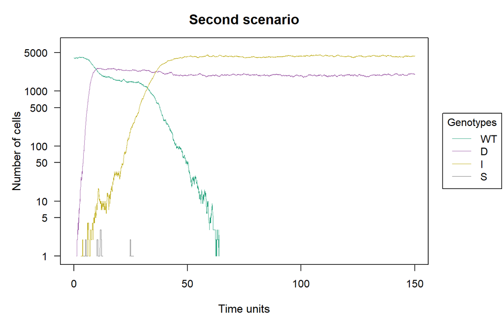

```r
scen2 <- allFitnessEffects(genotFitness = fitness_rel(a = 0.3, b = 0.7,
                                                     r = 0.1, g = 0.7),
                          frequencyDependentFitness = TRUE,
                          frequencyType = "rel")

simulScen2 <- oncoSimulIndiv(scen2,
                              model = "McFL",
                              onlyCancer = FALSE,
                              finalTime = 150,
                              mu = 1e-4,
                              initSize = 4000,
                              keepPhylog = TRUE,
                              seed = NULL,
                              errorHitMaxTries = FALSE,
                              errorHitWallTime = FALSE)

plot(simulScen2, show = "genotypes", type = "line",
     main = "Second scenario",
     cex.main = 1.3, cex.lab = 1.1,
     las = 1)
```

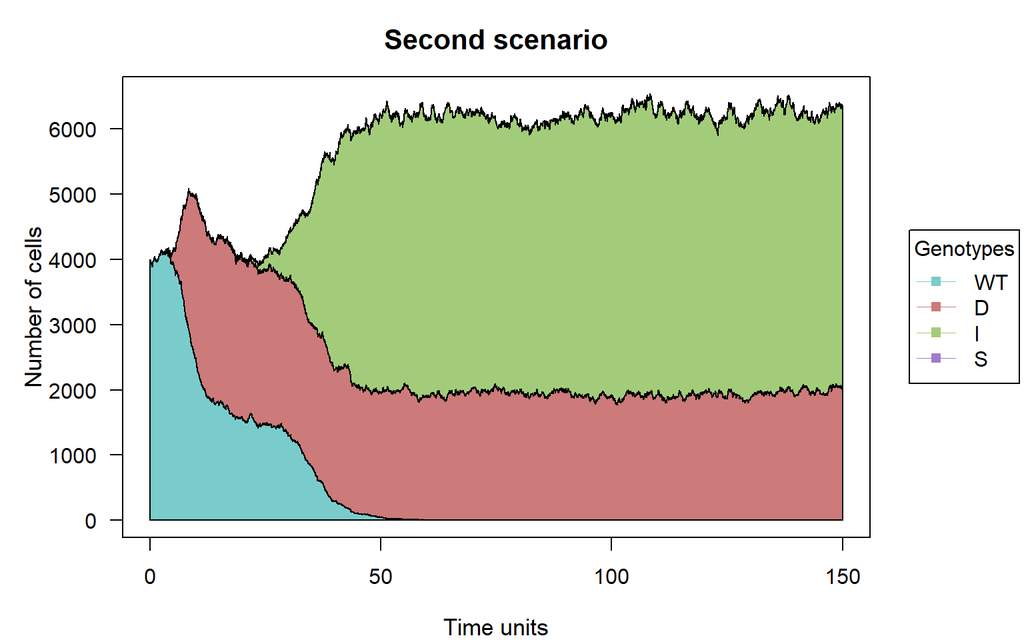

```r
plot(simulScen2, show = "genotypes",
     main = "Second scenario",
     cex.main = 1.3, cex.lab = 1.1,
     las = 1)
```

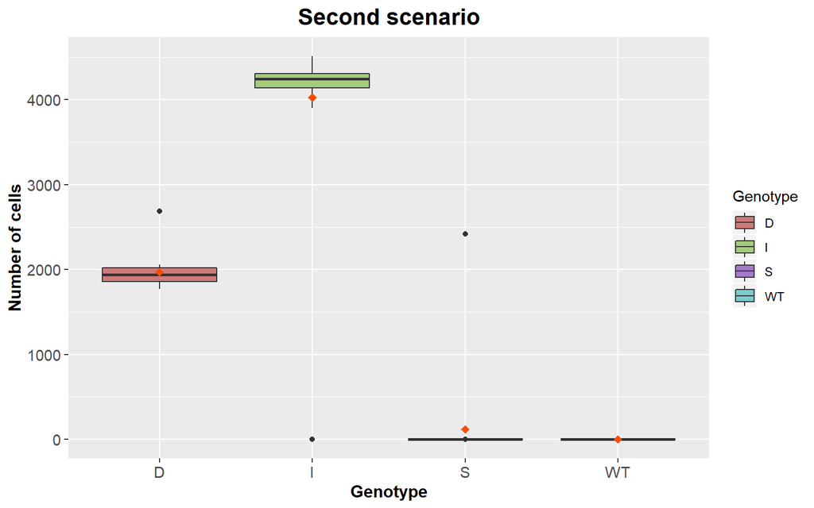

```r
simulScen2Pop <- oncoSimulPop(20,
                              scen2,
                              model = "McFL",
                              onlyCancer = FALSE,
                              mc.cores = n_cores,
                              finalTime = 150,
                              mu = 1e-4,
                              initSize = 4000,
                              keepPhylog = TRUE,
                              seed = NULL,
                              errorHitMaxTries = FALSE,
                              errorHitWallTime = FALSE)

compositionPop2(simulScen2Pop,
                main = "Second scenario",
                ylab = "Number of cells")
```

### 6.1.3 Third scenario

- $\alpha$ (a) = 0.2: low cooperation between D cells.
- $\beta$ (b) = 0.3: rich microenvironment, being beneficial for D cells.
- $\rho$ (r) = 0.1: low benefit of D cells from coexisting with I cells.
- $\gamma$ (g) = 0.3: independence costs very low, being beneficial for I cells.

Although $\gamma$ and $\rho$ are very low, which could make us think that I cells will control the tumour, we can observe that the fact that the microenvironment is very rich (with a low value of $\beta$) allows to D cells lead the progression of the tumour over the rest of cell populations, including I cells.

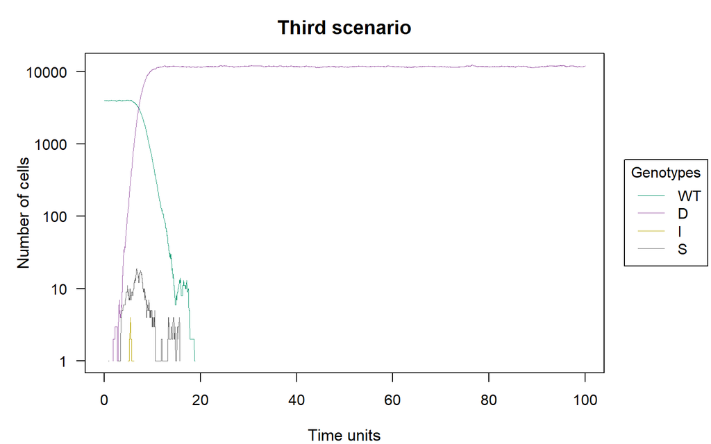

```r
scen3 <- allFitnessEffects(genotFitness = fitness_rel(a = 0.2, b = 0.3,
                                                     r = 0.1, g = 0.3),
                          frequencyDependentFitness = TRUE,
                          frequencyType = "rel")

simulScen3 <- oncoSimulIndiv(scen3,
                              model = "McFL",
                              onlyCancer = FALSE,
                              finalTime = 100,
                              mu = 1e-4,
                              initSize = 4000,
                              keepPhylog = TRUE,
                              seed = NULL,
                              errorHitMaxTries = FALSE,
                              errorHitWallTime = FALSE)

plot(simulScen3, show = "genotypes", type = "line",
     main = "Third scenario",
     cex.main = 1.3, cex.lab = 1.1,
     las = 1)
```

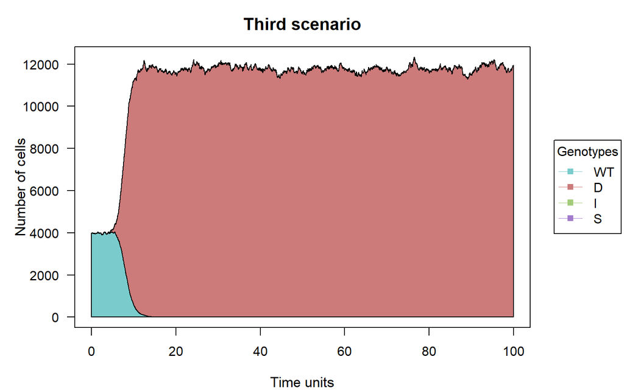

```r
plot(simulScen3, show = "genotypes",
     main = "Third scenario",
     cex.main = 1.3, cex.lab = 1.1,
     las = 1)
```

About the composition of populations, we can observe that the results are stable, showing that D cell population is bigger than the rest of cell populations.

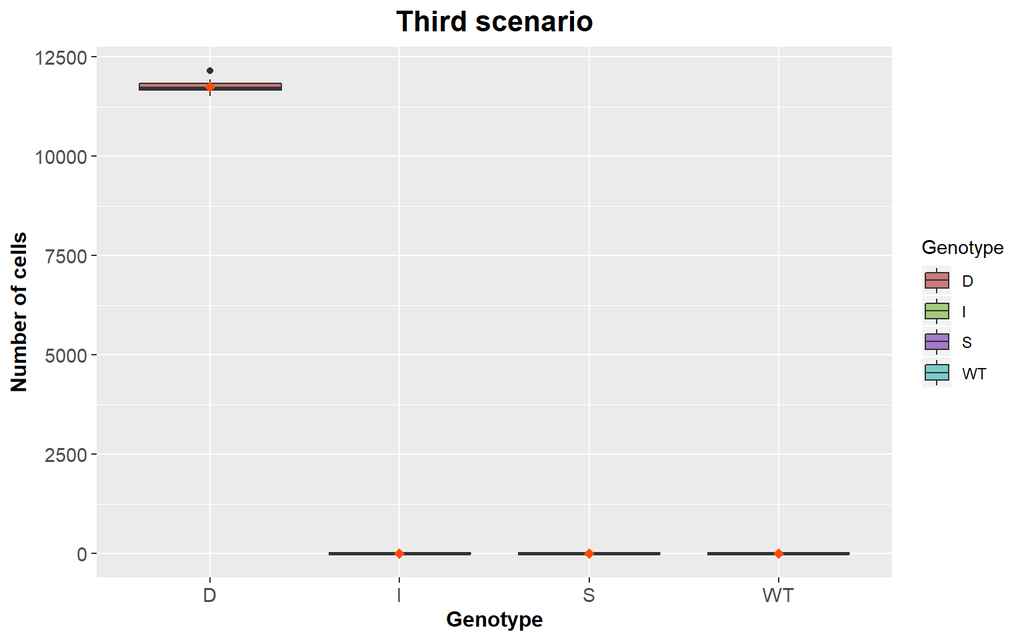

```r
simulScen3Pop <- oncoSimulPop(20,
                              scen3,
                              model = "McFL",
                              onlyCancer = FALSE,
                              mc.cores = n_cores,
                              finalTime = 150,
                              mu = 1e-3,
                              initSize = 4000,
                              keepPhylog = TRUE,
                              seed = NULL,
                              errorHitMaxTries = FALSE,
                              errorHitWallTime = FALSE)

compositionPop2(simulScen3Pop,
                main = "Third scenario",
                ylab = "Number of cells")
```

### 6.1.4 Fourth scenario

- $\alpha$ (a) = 0.2: low cooperation between D cells.
- $\beta$ (b) = 0.4: lower richness than in the previous scenario.
- $\rho$ (r) = 0.1: low benefit of D cells from coexisting with I cells.
- $\gamma$ (g) = 0.3: independence costs very low, being beneficial for I cells.

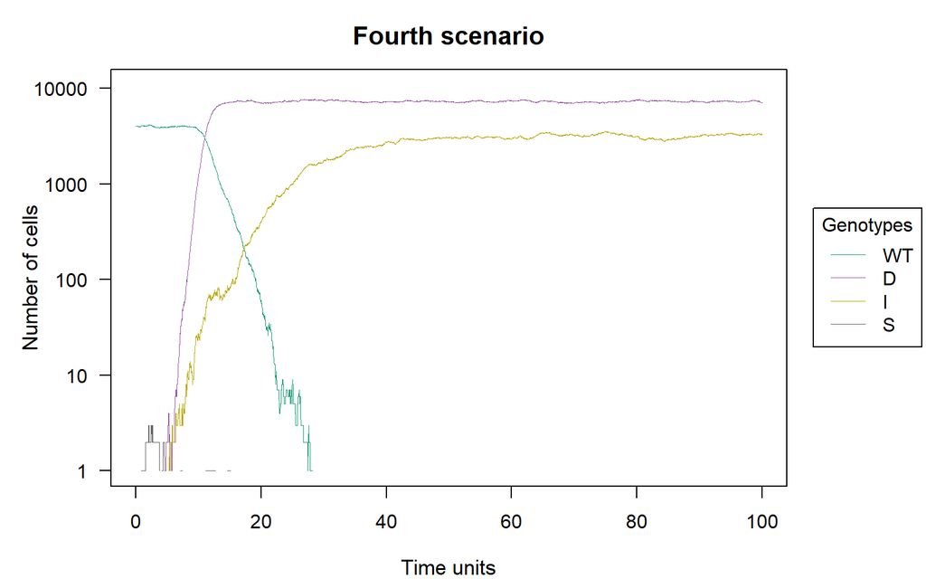

```r
scen4 <- allFitnessEffects(genotFitness = fitness_rel(a = 0.2, b = 0.4,
                                                     r = 0.1, g = 0.3),
                          frequencyDependentFitness = TRUE,
                          frequencyType = "rel")

## Set a different seed to show the results better since
## with set.seed(1) the progression of I cells was not shown
set.seed(2)

simulScen4 <- oncoSimulIndiv(scen4,
                              model = "McFL",
                              onlyCancer = FALSE,
                              finalTime = 100,
                              mu = 1e-4,
                              initSize = 4000,
                              keepPhylog = TRUE,
                              seed = NULL,
                              errorHitMaxTries = FALSE,
                              errorHitWallTime = FALSE)

plot(simulScen4, show = "genotypes", type = "line",
     main = "Fourth scenario",
     cex.main = 1.3, cex.lab = 1.1,
     las = 1)
```

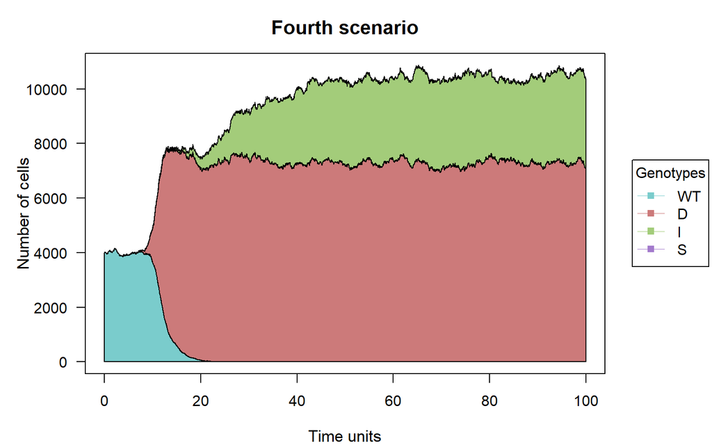

```r
plot(simulScen4, show = "genotypes",
     main = "Fourth scenario",
     cex.main = 1.3, cex.lab = 1.1,
     las = 1)
```

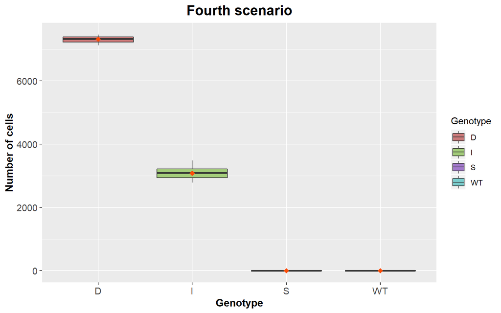

```r
simulScen4Pop <- oncoSimulPop(20,
                              scen4,
                              model = "McFL",
                              onlyCancer = FALSE,
                              mc.cores = n_cores,
                              finalTime = 150,
                              mu = 1e-3,
                              initSize = 4000,
                              keepPhylog = TRUE,
                              seed = NULL,
                              errorHitMaxTries = FALSE,
                              errorHitWallTime = FALSE)

compositionPop2(simulScen4Pop,
                main ="Fourth scenario",
                ylab = "Number of cells")
```

# 7 Evolutionary Dynamics of Tumor-Stroma Interactions in Multiple Myeloma

This example is based on the paper *Evolutionary Dynamics of Tumor-Stroma* *Interactions in Multiple Myeloma* [10], available at https://doi.org/10.1371/journal.pone.0168856. Here the authors provide a frequency-dependent model to study the growth of malignant plasma cells in Multiple Myeloma. Assuming that cancer cells and stromal cells cooperate by exchanging diffusible factors, the study is carried out in the framework of evolutionary game theory.

We first need to define a payoff strategy for this kind of scenario. The following definitions are needed:

- There are $n$ phenotypes in a population denoted by $\{ P_1, \ldots, P_n \}$.
- Each phenotype can produce one diffusible factor $\{ G_1, \ldots, G_n \}$.
- Each diffusible factor $j$ has a different effect $r_{i,j}$ on the other phenotypes $i$.
- The cost for $P_i$ for growth factor $G_i$ is denoted as $c_i$.
- $M$ is the number of cells within the diffusion range.
- There are $M_j$ individuals of type $P_j$ among the other group members.

Then, the payoff for strategy $P_j$ is:
$$\begin{align}
\pi_{P_j}(M_1,\ldots,M_n)=\frac{(M_j+1)\times c_j}{M}r_{j,j} +
\sum_{i=1, i \neq j}^n \frac{M_i \times c_i}{M}r_{j,i} - c_j \;.
\end{align}$$

$$\begin{align}
W_{OC} &= \frac{(f_{1}(M-1)+1)c_{1}}{M}r11+
\frac{((1-f_{3})(M-1)-f_{1}(M-1)-1)c_{2}}{M}r12 \\
&+\frac{(M-(1-f_3)(M-1))c_{3}}{M}r13-c_{1} \\
W_{OB} &= \frac{(f_{2}(M-1)+1)c_{2}}{M}r22+
\frac{((1-f_{1})(M-1)-f_{2}(M-1)-1)c_{3}}{M}r23 \\
&+\frac{(M-(1-f_{1})(M-1))c_{1}}{M}r21-c_{2} \\
W_{MM} &= \frac{(f_{3}(M-1)+1)c_{3}}{M}r33+
\frac{((1-f_{2})(M-1)-f_{3}(M-1)-1)c_{1}}{M}r31 \\
&+\frac{(M-(1-f_{2})(M-1))c_{2}}{M}r32-c_{3} \;,
\end{align}$$

where $f_1$, $f_2$ and $f_3$ denote the frequency of the phenotype OC, OB and MM in the population. The multiplication factors for diffusible factors produced by the cells are shown in the following table:

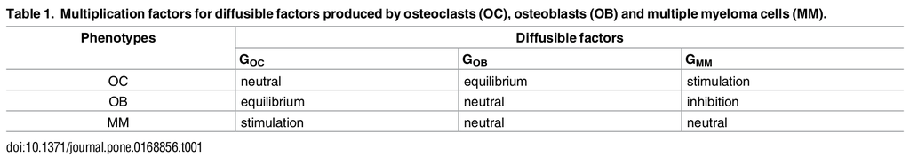

Multiplication factor in myeloma interaction

## 7.1 Simulations

First, we define the fitness of the different genotypes through the function *fitness_rel*.

```r
f_cells <- function(c1, c2, c3, r11, r12, r13,
                    r21, r22, r23, r31, r32, r33, M, awt = 1e-4,
                                 gt = c("WT", "OC", "OB", "MM")) {
    data.frame(Genotype = gt,
               Fitness = c(
                  paste0("max(0.1, 1 - ", awt, " * (f_1+f_2+f_3)*N)"),
                  paste0("1", "+(((f_1*(", M, "-1)+1)*", c1, ")/", M, ")*",r11,
                          "+((((1-f_3)*(", M, "-1)-f_1*(", M, "-1)-1)*", c2, ")/", M, ")*", r12,
                          "+(((", M, "-(1-f_3)*(", M, "-1))*", c3, ")/", M, ")*", r13,
                          "-", c1
                          ),
                  paste0("1", "+(((f_2*(", M, "-1)+1)*", c2, ")/", M, ")*", r22,
                          "+((((1-f_1)*(", M, "-1)-f_2*(", M, "-1)-1)*", c3, ")/", M, ")*", r23,
                          "+(((", M, "-(1-f_1)*(", M, "-1))*", c1, ")/", M, ")*", r21,
                          "-", c2
                          ),
                  paste0("1", "+(((f_3*(", M, "-1)+1)*", c3, ")/", M, ")*", r33,
                          "+((((1-f_2)*(", M, "-1)-f_3*(", M, "-1)-1)*", c1, ")/", M, ")*", r31,
                          "+(((", M, "-(1-f_2)*(", M, "-1))*", c2, ")/", M, ")*", r32,
                          "-", c3
                          )
                  )
               ,stringsAsFactors = FALSE
               )
}
```

It is important to note that, in order to exactly reproduce the experiments of the paper, we need to create an initial population with three different types of cell, but we do not need the presence of a wild type. For this reason, we will increase the probability of mutation of the wild type, which will disappear in early stages of the simulation. This is something that we must consider when interpreting the results.

### 7.1.1 Scenario 1

Here we model a common situation in multiple myeloma in which $c_1<c_2<c_3$. In the presence of a small number of MM cells, the stable point on the OB-OC border becomes a saddle point and clonal selection leads to a stable coexistence of OC and MM cells. Parameters for the simulation can be seen in the R code.

```r
N <- 40000
M <- 10
c1 <- 1
c2 <- 1.2
c3 <- 1.4
r11 <- 0
r12 <- 1
r13 <- 2.5
r21 <- 1
r22 <- 0
r23 <- -0.3
r31 <- 2.5
r32 <- 0
r33 <- 0

fe_cells <-
    allFitnessEffects(
        genotFitness =
            f_cells(c1, c2, c3, r11, r12, r13,
                    r21, r22, r23, r31, r32, r33, M,
                    gt = c("WT", "OC", "OB", "MM")),
        frequencyDependentFitness = TRUE,
        frequencyType = "rel")
```

```
## All single-gene genotypes as input to to_genotFitness_std
```

```r
## Simulated trajectories
simulation <- oncoSimulPop(20,
                           mc.cores = n_cores,
                           fe_cells,
                           model = "McFL",
                           onlyCancer = FALSE,
                           finalTime = 100,
                           mu = c("OC"=1e-1, "OB"=1e-1, "MM"=1e-4),
                           initSize = N,
                           keepPhylog = FALSE,
                           seed = NULL,
                           errorHitMaxTries = FALSE,
                           errorHitWallTime = FALSE)
```

```
## You are running Windows. Setting mc.cores = 1
```

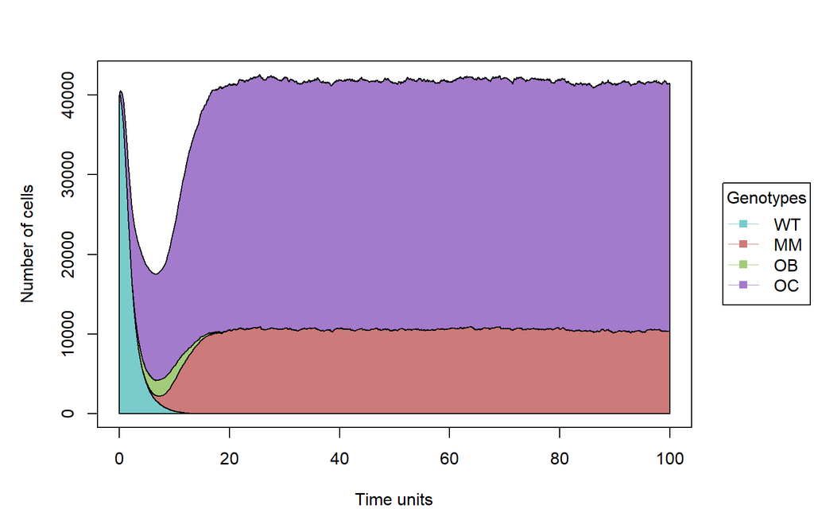

```r
#Plot trajectorie
plot(simulation[[1]], show = "genotypes")
```

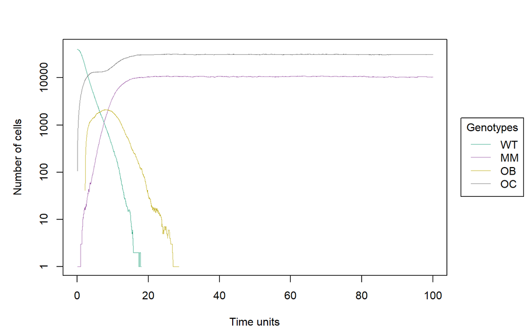

```r
plot(simulation[[1]], show = "genotypes", type = "line")
```

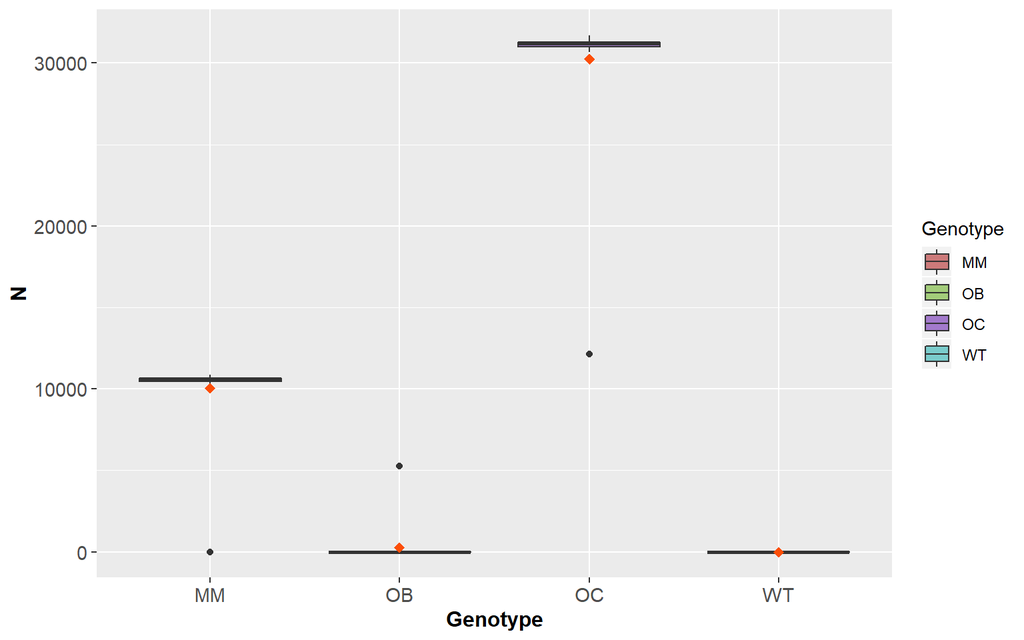

```r
## Agreement: Show boxplot from several simulations.
compositionPop2(simulation)
```

Clearly, the appearance of MM cells quickly brings the system to an equilibrium point, which is stable. OB cells are extinct and cancer has propelled.

### 7.1.2 Scenario 2

```r
N <- 40000
M <- 10
c1 <- 1
c2 <- 1
c3 <- 1
r11 <- 0
r12 <- 1
r13 <- 0.5
r21 <- 1
r22 <- 0
r23 <- -0.3
r31 <- 0.5
r32 <- 0
r33 <- 0

fe_cells <-
    allFitnessEffects(
        genotFitness =
            f_cells(c1, c2, c3, r11, r12, r13,
                    r21, r22, r23, r31, r32, r33, M,
                    gt = c("WT", "OC", "OB", "MM")),
        frequencyDependentFitness = TRUE,
        frequencyType = "rel")
```

```
## All single-gene genotypes as input to to_genotFitness_std
```

```r
## Simulated trajectories
simulation <- oncoSimulPop(20,
                           mc.cores = n_cores,
                           fe_cells,
                           model = "McFL",
                           onlyCancer = FALSE,
                           finalTime = 100,
                           mu = c("OC"=1e-1, "OB"=1e-1, "MM"=1e-4),
                           initSize = N,
                           keepPhylog = FALSE,
                           seed = NULL,
                           errorHitMaxTries = FALSE,
                           errorHitWallTime = FALSE)
```

```
## You are running Windows. Setting mc.cores = 1
```

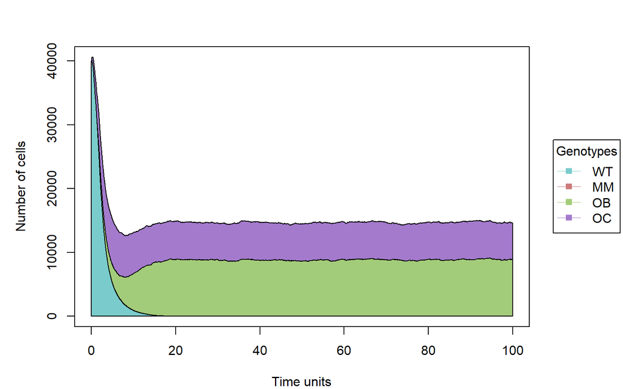

```r
#Plot trajectorie
plot(simulation[[1]], show = "genotypes")
```

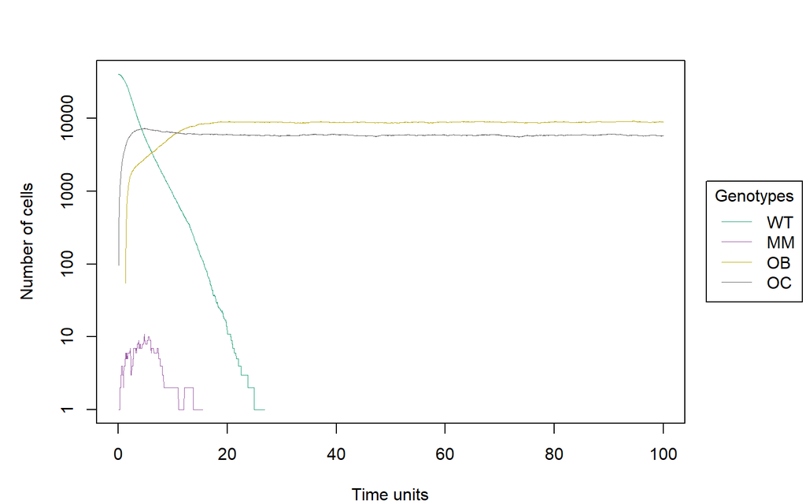

```r
plot(simulation[[1]], show = "genotypes", type = "line")
```

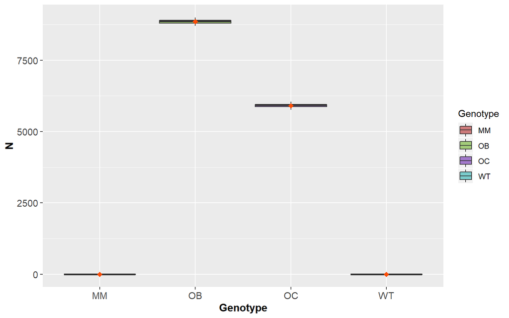

```r
## Agreement: Show boxplot from several simulations.
compositionPop2(simulation)
```

As expected, under these condtitions, MM cells are not able to propagate. The equilibrium point in the OB-OC edge is stable, resisting small variations in the number of MM cells.

### 7.1.3 Scenario 3

```r
N <- 40000
M <- 50
c1 <- 1
c2 <- 1.2
c3 <- 0.8
r11 <- 0
r12 <- 1
r13 <- 0.5
r21 <- 1
r22 <- 0
r23 <- -0.3
r31 <- 0.5
r32 <- 0
r33 <- 0

fe_cells <-
    allFitnessEffects(
        genotFitness =
            f_cells(c1, c2, c3, r11, r12, r13,
                    r21, r22, r23, r31, r32, r33, M,
                    gt = c("WT", "OC", "OB", "MM")),
        frequencyDependentFitness = TRUE,
        frequencyType = "rel")
```

```
## All single-gene genotypes as input to to_genotFitness_std
```

```r
## Simulated trajectories
simulation <- oncoSimulPop(20,
                           mc.cores = n_cores,
                           fe_cells,
                           model = "McFL",
                           onlyCancer = FALSE,
                           finalTime = 100,
                           mu = c("OC"=1e-1, "OB"=1e-1, "MM"=1e-4),
                           initSize = N,
                           keepPhylog = FALSE,
                           seed = NULL,
                           errorHitMaxTries = FALSE,
                           errorHitWallTime = FALSE)
```

```
## You are running Windows. Setting mc.cores = 1
```

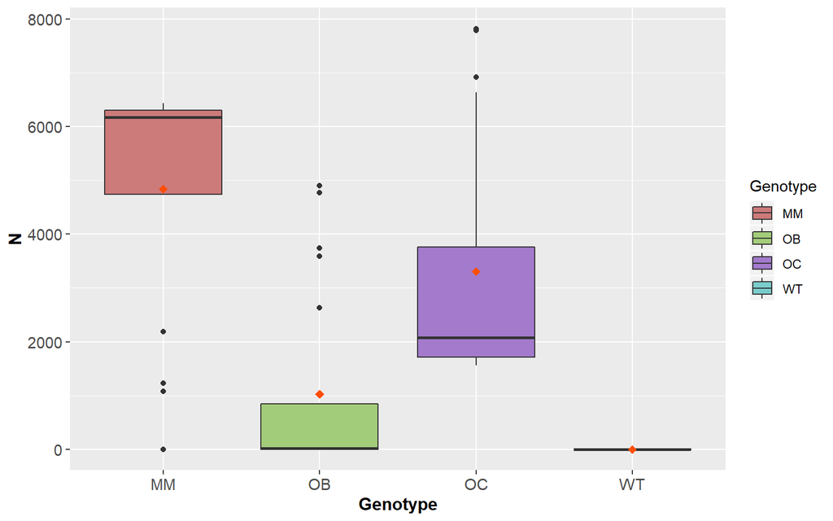

```r
## Agreement: Show boxplot from several simulations.
compositionPop2(simulation)
```

# 8 References

[1]. Archetti, M., Pienta, K.J. Cooperation among cancer cells: applying game theory to cancer. Nat Rev Cancer 19, 110–117 (2019) doi:10.1038/s41568-018-0083-7

[2]. Basanta, D., Scott, J., Fishman, M. et al. Investigating prostate cancer tumour–stroma interactions: clinical and biological insights from an evolutionary game. Br J Cancer 106, 174–181 (2012) doi:10.1038/bjc.2011.517

[3]. Chicken (game) [Internet]. En.wikipedia.org. 2020 [cited 7 January 2020]. Available from: https://en.wikipedia.org/wiki/Chicken_(game)

[4]. Diaz-Uriarte R (2017). “OncoSimulR: genetic simulation with arbitrary epistasis and mutator genes in asexual populations.” Bioinformatics, 33(12), 1898–1899. doi: 10.1093/bioinformatics/btx077, https://doi.org/10.1093/bioinformatics/btx077.

[5] Diaz-Uriarte R (2017). “Cancer progression models and fitness landscapes: a many-to-many relationship.” Bioinformatics. doi: 10.1093/bioinformatics/btx663, https://academic.oup.com/bioinformatics/advance-article/doi/10.1093/bioinformatics/btx663/.

[6] Diaz-Uriarte R (2015). “Identifying restrictions in the order of accumulation of mutations during tumor progression: effects of passengers, evolutionary models, and sampling.” BMC Bioinformatics, 16(41). doi: 10.1186/s12859-015-0466-7, http://www.biomedcentral.com/1471-2105/16/41/abstract.

[7]. Kaznatcheev, A., Vander Velde, R., Scott, J. et al. Cancer treatment scheduling and dynamic heterogeneity in social dilemmas of tumour acidity and vasculature. Br J Cancer 116, 785–792 (2017) doi:10.1038/bjc.2017.5

[8]. Kerr, B., Riley, M., Feldman, M. et al. Local dispersal promotes biodiversity in a real-life game of rock–paper–scissors. Nature 418, 171–174 (2002) doi:10.1038/nature00823

[9]. Ramon Diaz-Uriarte, Sergio Sanchez-Carrillo. OncoSimulR: forward genetic simulation in asexual populations with arbitrary epistatic interactions and a focus on modeling tumor progression (2019). -> Vignette

[10]. Sartakhti, J. S., Manshaei, M. H., Bateni, S., & Archetti, M. (2016). Evolutionary dynamics of tumor-stroma interactions in multiple myeloma. PloS one, 11(12), e0168856.

[11]. Sergio Sánchez Carrillo, Ramón Díaz Uriarte. Implementación del fitness dependiente de la frecuencia genética en el paquete OncoSimulR (2018). -> TFM

[12]. Williams BK, Nichols JD, Conroy MJ Michael J. Analysis and management of animal populations: modeling, estimation, and decision making. Academic Press; 2002. 817 p